# Problem 5. Indicator Variables

Tyler Sotomayor

2025-06-30

**Course**: STAT 1201 | Introduction to Calc-based Statistics  
**Instructors**: Jonas Mikhaeil, Tina Giorgadze  
**Assignment**: Homework 5 – Problem 5

This exercise from *Homework 5 of STAT 1201 | Introduction to Calc-based Statistics (Summer 2025, Jonas Mikhaeil)* explores how to use indicator variables in a linear regression model to predict student test scores based on the following regressors:

- Pre-test scores,
- Sex (binary: male or female),
- Grade level (6, 7, or 8).

We compare two different ways to include grade in the model. First, as a numeric (linear) predictor. Second, as a categorical variable (with indicator variables).

**Explicit answers to problem 5(a) and 5(b) can be found under “Model A” and “Model B”**

## Simulate Data

Before we begin, we will first simulate a dataset of student records to test our models and validate our code.

```r
# Load necessary package
library(tidyverse)  # Provides tools like dplyr, ggplot2, and tibble

# Set seed so results are reproducible each time you knit the document
set.seed(123)

# Create a fake dataset with 100 students
mydata <- data.frame(
  pre_test = runif(100, 0, 100),             # Random scores between 0–100
  sex = sample(0:1, 100, replace = TRUE),    # 0 = female, 1 = male (binary coding)
  grade = sample(6:8, 100, replace = TRUE)   # Randomly assign grade level: 6, 7, or 8
)

# Now generate the outcome variable (test_score)
# We assume:
#   - Higher pre_test scores improve final scores
#   - Males score slightly higher on average (sex effect)
#   - Higher grades have slightly higher performance
#   - Add noise using rnorm() to simulate real-world randomness

mydata$test_score <- 0.5 * mydata$pre_test +     # strong effect of prior performance
                     5 * mydata$sex +            # moderate effect of sex (male = 1)
                     2 * mydata$grade +          # increasing grade level = higher score
                     rnorm(100, mean = 0, sd = 10) # random noise (residual variation)
```

## Model A: Treating Grade as a Linear Variable

In this model, we treat ‘grade’ as a numeric linear predictor assuming a linear relationship between grade and test score.

```r
model_linear <- lm(test_score ~ pre_test + sex + grade, data = mydata)

# Print summary to view estimated coefficients, standard errors, etc.
summary(model_linear)
```

```
##
## Call:
## lm(formula = test_score ~ pre_test + sex + grade, data = mydata)
##
## Residuals:
##      Min       1Q   Median       3Q      Max
## -31.0806  -7.6488  -0.5166   7.4058  27.0164
##
## Coefficients:
##              Estimate Std. Error t value Pr(>|t|)
## (Intercept) -13.27166   10.20972  -1.300  0.19675
## pre_test      0.50889    0.03948  12.889  < 2e-16 ***
## sex           5.58067    2.24053   2.491  0.01446 *
## grade         3.80383    1.40471   2.708  0.00802 **
## ---
## Signif. codes:  0 '***' 0.001 '**' 0.01 '*' 0.05 '.' 0.1 ' ' 1
##
## Residual standard error: 11.02 on 96 degrees of freedom
## Multiple R-squared:  0.6365, Adjusted R-squared:  0.6251
## F-statistic: 56.03 on 3 and 96 DF,  p-value: < 2.2e-16
```

The estimated regression model suggests that, holding pre-test scores and sex constant, a one-unit increase in grade level (e.g., from grade 6 to 7, or from 7 to 8) is associated with an average increase of approximately 3.80 points in the test score (p = 0.008). This effect is statistically significant at the 1% level, indicating strong evidence of a positive linear relationship between grade level and test performance in the simulated data.

Additionally, pre-test scores have a large and highly significant positive effect: for every one-point increase in pre-test score, the expected test score increases by approximately 0.51 points (p < 0.001). The binary variable for sex (coded as 1 for male, 0 for female) indicates that male students, on average, score about 5.58 points higher than female students, controlling for grade and pre-test performance (p = 0.014).

The overall model explains approximately 63.65% of the variance in test scores (R² = 0.6365), with an adjusted R² of 0.6251, indicating strong model fit.

## Model B: Treating Grade as a Categorical Variable (Indicators)

To answer Problem 5(b) we use R’s built-in factor() function to treat grade as a categorical variable. R assigns dummy (indicator) variables for grade 7 and 8, allowing us to estimate separate effects for each grade level relative to grade 6 (the baseline category). We treat Grade 6 as the “baseline” (intercept includes grade 6). This model estimates the effect of being in grade 7 or 8 relative to grade 6. *Note: this approach makes no assumption about the relationship between grade level and test scores being linear…*

```r
model_indicators <- lm(test_score ~ pre_test + sex + factor(grade), data = mydata)

# View the summary output
summary(model_indicators)
```

```
##
## Call:
## lm(formula = test_score ~ pre_test + sex + factor(grade), data = mydata)
##
## Residuals:
##      Min       1Q   Median       3Q      Max
## -31.1817  -7.4822  -0.4743   7.3266  27.2364
##
## Coefficients:
##                Estimate Std. Error t value Pr(>|t|)
## (Intercept)     9.61772    3.07351   3.129  0.00233 **
## pre_test        0.50962    0.03994  12.759  < 2e-16 ***
## sex             5.56269    2.25474   2.467  0.01541 *
## factor(grade)7  3.45911    2.56345   1.349  0.18042
## factor(grade)8  7.69758    2.87841   2.674  0.00882 **
## ---
## Signif. codes:  0 '***' 0.001 '**' 0.01 '*' 0.05 '.' 0.1 ' ' 1
##
## Residual standard error: 11.08 on 95 degrees of freedom
## Multiple R-squared:  0.6366, Adjusted R-squared:  0.6213
## F-statistic:  41.6 on 4 and 95 DF,  p-value: < 2.2e-16
```

In this specification, grade level is modeled as a categorical variable with grade 6 serving as the reference category. The regression results indicate that, controlling for pre-test scores and sex, students in grade 8 score on average 7.70 points higher than students in grade 6 (p = 0.0088). This difference is statistically significant at the 1% level. Students in grade 7, by contrast, score on average 3.46 points higher than students in grade 6, although this estimate is not statistically significant (p = 0.1804), suggesting that the score difference between grades 6 and 7 is not reliably different from zero in this sample.

The effect of pre-test scores remains strong and significant: a one-point increase in pre-test score is associated with an average increase of 0.51 points in the test score (p < 0.001), nearly identical to the linear-grade model. The sex coefficient indicates that male students score on average 5.56 points higher than female students, holding other variables constant (p = 0.015).

This model explains approximately 63.66% of the variation in test scores (R² = 0.6366), with an adjusted R² of 0.6213. These values are nearly identical to those from the linear-grade model, indicating that the added flexibility of using indicators does not meaningfully improve model fit in this case — likely because the relationship between grade and test score is already close to linear in the underlying data generating process!

## Comparison of Model Coefficients

```r
# Load broom if not already loaded
library(broom)

# Extract and label tidy summaries of both models
coeff_table <- bind_rows(
  tidy(model_linear) %>% mutate(Model = "Linear Grade"),
  tidy(model_indicators) %>% mutate(Model = "Indicator Grade")
)

# Select key columns and reshape into wide format for comparison
coeff_table %>%
  select(Model, term, estimate, std.error) %>%
  pivot_wider(
    names_from = Model,
    values_from = c(estimate, std.error),
    names_glue = "{Model}_{.value}"
  ) %>%
  knitr::kable(
    digits = 2,
    caption = "Comparison of Estimated Coefficients Across Models",
    align = "lcc"
  )
```

Comparison of Estimated Coefficients Across Models

| term | Linear Grade_estimate | Indicator Grade_estimate | Linear Grade_std.error | Indicator Grade_std.error |
| --- | --- | --- | --- | --- |
| (Intercept) | -13.27 | 9.62 | 10.21 | 3.07 |
| pre_test | 0.51 | 0.51 | 0.04 | 0.04 |
| sex | 5.58 | 5.56 | 2.24 | 2.25 |
| grade | 3.80 | NA | 1.40 | NA |
| factor(grade)7 | NA | 3.46 | NA | 2.56 |
| factor(grade)8 | NA | 7.70 | NA | 2.88 |

## Comparison of Model Fit

```r
# Compare how much variance in test_score is explained by each model
tibble(
  Model = c("Linear Grade", "Indicator Grade"),
  R_squared = c(summary(model_linear)$r.squared,
                summary(model_indicators)$r.squared)
)
```

```
## # A tibble: 2 × 2
##   Model           R_squared
##   <chr>               <dbl>
## 1 Linear Grade        0.636
## 2 Indicator Grade     0.637
```

The near-identical R² values confirm that in this specific simulated dataset the relationship between grade and test score is linear.

## Plots: Model Diagnostics and Validation of Model Assumptions

Finally I generate a couple plots to validate our code and check assumptions of our linear model specification (linearity, normality of residuals, homoskedasticity, no wild outliers)

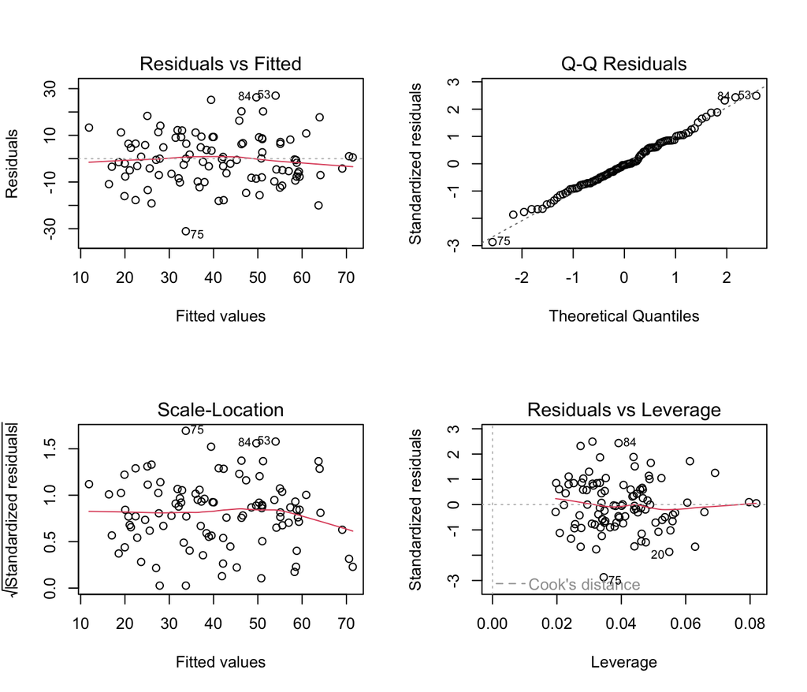

```r
# 2x2 plotting grid
par(mfrow = c(2, 2))

# Plot diagnostics for the linear grade model
plot(model_linear)
```